# ANCOVA in flow (prod. textual) (flow (prod. textual))

Geiser C. Challco geiser@alumni.usp.br

- Descriptive Statistics of Initial Data
- ANCOVA and Pairwise for one factor: **grupo**
  - Without remove non-normal data
  - Computing ANCOVA and PairWise After removing non-normal data (OK)
    - Plots for ancova
    - Checking linearity assumption
    - Checking normality and homogeneity
- ANCOVA and Pairwise for two factors **grupo:Sexo**
  - Without remove non-normal data
  - Computing ANCOVA and PairWise After removing non-normal data (OK)
    - Plots for ancova
    - Checking linearity assumption
    - Checking normality and homogeneity
- ANCOVA and Pairwise for two factors **grupo:Zona**
  - Without remove non-normal data
  - Computing ANCOVA and PairWise After removing non-normal data (OK)
    - Plots for ancova
    - Checking linearity assumption
    - Checking normality and homogeneity
- ANCOVA and Pairwise for two factors **grupo:Cor.Raca**
  - Without remove non-normal data
  - Computing ANCOVA and PairWise After removing non-normal data (OK)
    - Plots for ancova
    - Checking linearity assumption
    - Checking normality and homogeneity
- Summary of Results
  - Descriptive Statistics
  - ANCOVA Table Comparison
  - PairWise Table Comparison
  - EMMS Table Comparison

**NOTE**:

- Teste ANCOVA para determinar se houve diferenças significativas no flow (prod. textual) (medido usando pre- e pos-testes).
- ANCOVA test to determine whether there were significant differences in flow (prod. textual) (measured using pre- and post-tests).

# Descriptive Statistics of Initial Data

```r
df <- get.descriptives(dat, c(dv.pre, dv.pos), c("grupo"),
                       include.global = T, symmetry.test = T, normality.test = F)
df <- plyr::rbind.fill(
  df, do.call(plyr::rbind.fill, lapply(lfatores2, FUN = function(f) {
    if (nrow(dat) > 0 && sum(!is.na(unique(dat[[f]]))) > 1)
      get.descriptives(dat, c(dv.pre,dv.pos), c("grupo", f),
                       symmetry.test = T, normality.test = F)
    }))
)
(df <- df[,c(fatores1[fatores1 %in% colnames(df)],"variable",
             colnames(df)[!colnames(df) %in% c(fatores1,"variable")])])
```

```
##           grupo Sexo   Zona Cor.Raca       variable   n  mean median   min   max    sd    se    ci   iqr
## 1      Controle <NA>   <NA>     <NA> dfs.media.text 151 3.486  3.444 1.444 5.000 0.632 0.051 0.102 0.778
## 2  Experimental <NA>   <NA>     <NA> dfs.media.text 171 3.404  3.444 2.222 5.000 0.574 0.044 0.087 0.778
## 3          <NA> <NA>   <NA>     <NA> dfs.media.text 322 3.442  3.444 1.444 5.000 0.602 0.034 0.066 0.889
## 4      Controle <NA>   <NA>     <NA> fss.media.text 151 3.453  3.333 1.000 5.000 0.610 0.050 0.098 0.778
## 5  Experimental <NA>   <NA>     <NA> fss.media.text 171 3.448  3.444 1.889 5.000 0.570 0.044 0.086 0.778
## 6          <NA> <NA>   <NA>     <NA> fss.media.text 322 3.451  3.444 1.000 5.000 0.588 0.033 0.065 0.778
## 7      Controle    F   <NA>     <NA> dfs.media.text  70 3.604  3.556 1.889 4.778 0.633 0.076 0.151 0.861
## 8      Controle    M   <NA>     <NA> dfs.media.text  81 3.384  3.444 1.444 5.000 0.616 0.068 0.136 0.667
## 9  Experimental    F   <NA>     <NA> dfs.media.text  91 3.466  3.444 2.222 5.000 0.540 0.057 0.112 0.722
## 10 Experimental    M   <NA>     <NA> dfs.media.text  80 3.332  3.354 2.222 4.778 0.606 0.068 0.135 0.778
## 11     Controle    F   <NA>     <NA> fss.media.text  70 3.591  3.444 2.222 4.667 0.560 0.067 0.134 0.778
## 12     Controle    M   <NA>     <NA> fss.media.text  81 3.334  3.222 1.000 5.000 0.629 0.070 0.139 0.889
## 13 Experimental    F   <NA>     <NA> fss.media.text  91 3.450  3.444 1.889 5.000 0.618 0.065 0.129 0.833
## 14 Experimental    M   <NA>     <NA> fss.media.text  80 3.446  3.410 2.375 4.556 0.515 0.058 0.115 0.694
```

[output cut: 79 more lines]

| grupo | Sexo | Zona | Cor.Raca | variable | n | mean | median | min | max | sd | se | ci | iqr | symmetry | skewness | kurtosis |
| --- | --- | --- | --- | --- | --- | --- | --- | --- | --- | --- | --- | --- | --- | --- | --- | --- |
| Controle |  |  |  | dfs.media.text | 151 | 3.486 | 3.444 | 1.444 | 5.000 | 0.632 | 0.051 | 0.102 | 0.778 | YES | -0.101 | 0.254 |
| Experimental |  |  |  | dfs.media.text | 171 | 3.404 | 3.444 | 2.222 | 5.000 | 0.574 | 0.044 | 0.087 | 0.778 | YES | 0.092 | -0.350 |
|  |  |  |  | dfs.media.text | 322 | 3.442 | 3.444 | 1.444 | 5.000 | 0.602 | 0.034 | 0.066 | 0.889 | YES | 0.007 | 0.010 |
| Controle |  |  |  | fss.media.text | 151 | 3.453 | 3.333 | 1.000 | 5.000 | 0.610 | 0.050 | 0.098 | 0.778 | YES | -0.195 | 0.798 |
| Experimental |  |  |  | fss.media.text | 171 | 3.448 | 3.444 | 1.889 | 5.000 | 0.570 | 0.044 | 0.086 | 0.778 | YES | 0.090 | -0.256 |
|  |  |  |  | fss.media.text | 322 | 3.451 | 3.444 | 1.000 | 5.000 | 0.588 | 0.033 | 0.065 | 0.778 | YES | -0.058 | 0.342 |
| Controle | F |  |  | dfs.media.text | 70 | 3.604 | 3.556 | 1.889 | 4.778 | 0.633 | 0.076 | 0.151 | 0.861 | YES | -0.173 | -0.348 |
| Controle | M |  |  | dfs.media.text | 81 | 3.384 | 3.444 | 1.444 | 5.000 | 0.616 | 0.068 | 0.136 | 0.667 | YES | -0.069 | 0.861 |
| Experimental | F |  |  | dfs.media.text | 91 | 3.466 | 3.444 | 2.222 | 5.000 | 0.540 | 0.057 | 0.112 | 0.722 | YES | 0.212 | -0.326 |
| Experimental | M |  |  | dfs.media.text | 80 | 3.332 | 3.354 | 2.222 | 4.778 | 0.606 | 0.068 | 0.135 | 0.778 | YES | 0.069 | -0.534 |
| Controle | F |  |  | fss.media.text | 70 | 3.591 | 3.444 | 2.222 | 4.667 | 0.560 | 0.067 | 0.134 | 0.778 | YES | 0.031 | -0.670 |
| Controle | M |  |  | fss.media.text | 81 | 3.334 | 3.222 | 1.000 | 5.000 | 0.629 | 0.070 | 0.139 | 0.889 | YES | -0.235 | 1.380 |
| Experimental | F |  |  | fss.media.text | 91 | 3.450 | 3.444 | 1.889 | 5.000 | 0.618 | 0.065 | 0.129 | 0.833 | YES | 0.000 | -0.290 |
| Experimental | M |  |  | fss.media.text | 80 | 3.446 | 3.410 | 2.375 | 4.556 | 0.515 | 0.058 | 0.115 | 0.694 | YES | 0.256 | -0.554 |
| Controle |  | Rural |  | dfs.media.text | 100 | 3.580 | 3.472 | 2.222 | 4.778 | 0.598 | 0.060 | 0.119 | 1.000 | YES | 0.143 | -0.816 |
| Controle |  | Urbana |  | dfs.media.text | 30 | 3.344 | 3.333 | 1.444 | 5.000 | 0.727 | 0.133 | 0.271 | 0.556 | YES | -0.376 | 0.967 |
| Controle |  |  |  | dfs.media.text | 21 | 3.240 | 3.222 | 1.889 | 4.333 | 0.564 | 0.123 | 0.257 | 0.556 | YES | -0.283 | -0.032 |
| Experimental |  | Rural |  | dfs.media.text | 85 | 3.384 | 3.444 | 2.222 | 5.000 | 0.576 | 0.062 | 0.124 | 0.778 | YES | 0.038 | -0.322 |
| Experimental |  | Urbana |  | dfs.media.text | 41 | 3.360 | 3.250 | 2.333 | 4.556 | 0.485 | 0.076 | 0.153 | 0.444 | YES | 0.211 | -0.146 |
| Experimental |  |  |  | dfs.media.text | 45 | 3.479 | 3.556 | 2.222 | 4.778 | 0.647 | 0.096 | 0.194 | 1.000 | YES | 0.001 | -0.821 |
| Controle |  | Rural |  | fss.media.text | 100 | 3.522 | 3.444 | 1.000 | 4.667 | 0.623 | 0.062 | 0.124 | 0.819 | NO | -0.580 | 1.382 |
| Controle |  | Urbana |  | fss.media.text | 30 | 3.385 | 3.278 | 2.222 | 5.000 | 0.599 | 0.109 | 0.224 | 0.750 | YES | 0.429 | 0.071 |
| Controle |  |  |  | fss.media.text | 21 | 3.226 | 3.222 | 2.444 | 4.556 | 0.513 | 0.112 | 0.234 | 0.444 | NO | 0.932 | 0.708 |
| Experimental |  | Rural |  | fss.media.text | 85 | 3.474 | 3.444 | 2.333 | 4.667 | 0.545 | 0.059 | 0.118 | 0.778 | YES | -0.005 | -0.406 |
| Experimental |  | Urbana |  | fss.media.text | 41 | 3.320 | 3.333 | 2.375 | 4.556 | 0.568 | 0.089 | 0.179 | 0.778 | YES | 0.434 | -0.484 |
| Experimental |  |  |  | fss.media.text | 45 | 3.517 | 3.444 | 1.889 | 5.000 | 0.612 | 0.091 | 0.184 | 0.889 | YES | -0.060 | 0.074 |
| Controle |  |  | Branca | dfs.media.text | 20 | 3.506 | 3.444 | 2.750 | 4.444 | 0.533 | 0.119 | 0.250 | 0.917 | YES | 0.238 | -1.441 |
| Controle |  |  | Indígena | dfs.media.text | 3 | 3.704 | 4.222 | 2.667 | 4.222 | 0.898 | 0.519 | 2.231 | 0.778 | few data | 0.000 | 0.000 |
| Controle |  |  | Parda | dfs.media.text | 42 | 3.669 | 3.625 | 2.222 | 5.000 | 0.624 | 0.096 | 0.194 | 0.889 | YES | 0.177 | -0.578 |
| Controle |  |  | Preta | dfs.media.text | 1 | 3.333 | 3.333 | 3.333 | 3.333 |  |  |  | 0.000 | few data | 0.000 | 0.000 |
| Controle |  |  |  | dfs.media.text | 85 | 3.385 | 3.444 | 1.444 | 4.778 | 0.640 | 0.069 | 0.138 | 0.778 | YES | -0.242 | 0.521 |
| Experimental |  |  | Branca | dfs.media.text | 17 | 3.399 | 3.444 | 2.222 | 4.111 | 0.563 | 0.136 | 0.289 | 0.667 | YES | -0.458 | -0.719 |
| Experimental |  |  | Indígena | dfs.media.text | 12 | 3.337 | 3.465 | 2.667 | 4.222 | 0.488 | 0.141 | 0.310 | 0.806 | YES | 0.016 | -1.286 |
| Experimental |  |  | Parda | dfs.media.text | 44 | 3.217 | 3.222 | 2.222 | 4.444 | 0.520 | 0.078 | 0.158 | 0.694 | YES | 0.230 | -0.551 |
| Experimental |  |  | Preta | dfs.media.text | 1 | 3.333 | 3.333 | 3.333 | 3.333 |  |  |  | 0.000 | few data | 0.000 | 0.000 |
| Experimental |  |  |  | dfs.media.text | 97 | 3.498 | 3.556 | 2.222 | 5.000 | 0.597 | 0.061 | 0.120 | 0.778 | YES | 0.026 | -0.350 |
| Controle |  |  | Branca | fss.media.text | 20 | 3.568 | 3.389 | 2.667 | 4.556 | 0.481 | 0.108 | 0.225 | 0.576 | YES | 0.437 | -0.676 |
| Controle |  |  | Indígena | fss.media.text | 3 | 3.852 | 4.222 | 2.889 | 4.444 | 0.841 | 0.486 | 2.090 | 0.778 | few data | 0.000 | 0.000 |
| Controle |  |  | Parda | fss.media.text | 42 | 3.558 | 3.556 | 2.222 | 5.000 | 0.627 | 0.097 | 0.195 | 0.823 | YES | 0.069 | -0.354 |
| Controle |  |  | Preta | fss.media.text | 1 | 3.000 | 3.000 | 3.000 | 3.000 |  |  |  | 0.000 | few data | 0.000 | 0.000 |
| Controle |  |  |  | fss.media.text | 85 | 3.366 | 3.333 | 1.000 | 4.667 | 0.615 | 0.067 | 0.133 | 0.889 | YES | -0.393 | 1.256 |
| Experimental |  |  | Branca | fss.media.text | 17 | 3.358 | 3.333 | 2.375 | 4.444 | 0.665 | 0.161 | 0.342 | 1.111 | YES | 0.103 | -1.243 |
| Experimental |  |  | Indígena | fss.media.text | 12 | 3.471 | 3.444 | 2.778 | 4.667 | 0.576 | 0.166 | 0.366 | 0.809 | YES | 0.458 | -0.828 |
| Experimental |  |  | Parda | fss.media.text | 44 | 3.482 | 3.444 | 2.375 | 4.667 | 0.521 | 0.079 | 0.159 | 0.667 | YES | 0.308 | -0.391 |
| Experimental |  |  | Preta | fss.media.text | 1 | 4.333 | 4.333 | 4.333 | 4.333 |  |  |  | 0.000 | few data | 0.000 | 0.000 |
| Experimental |  |  |  | fss.media.text | 97 | 3.437 | 3.444 | 1.889 | 5.000 | 0.576 | 0.059 | 0.116 | 0.889 | YES | 0.014 | -0.084 |

# ANCOVA and Pairwise for one factor: **grupo**

## Without remove non-normal data

```r
pdat = remove_group_data(dat[!is.na(dat[["grupo"]]),], "fss.media.text", "grupo")

pdat.long <- rbind(pdat[,c("id","grupo")], pdat[,c("id","grupo")])
pdat.long[["time"]] <- c(rep("pre", nrow(pdat)), rep("pos", nrow(pdat)))
pdat.long[["time"]] <- factor(pdat.long[["time"]], c("pre","pos"))
pdat.long[["flow.text"]] <- c(pdat[["dfs.media.text"]], pdat[["fss.media.text"]])

aov = anova_test(pdat, fss.media.text ~ dfs.media.text + grupo)
laov[["grupo"]] <- get_anova_table(aov)
```

```r
pwc <- emmeans_test(pdat, fss.media.text ~ grupo, covariate = dfs.media.text,
                    p.adjust.method = "bonferroni")
```

```r
pwc.long <- emmeans_test(dplyr::group_by_at(pdat.long, "grupo"),
                          flow.text ~ time,
                          p.adjust.method = "bonferroni")
lpwc[["grupo"]] <- plyr::rbind.fill(pwc, pwc.long)
```

```r
ds <- get.descriptives(pdat, "fss.media.text", "grupo", covar = "dfs.media.text")
ds <- merge(ds[ds$variable != "dfs.media.text",],
            ds[ds$variable == "dfs.media.text", !colnames(ds) %in% c("variable")],
            by = "grupo", all.x = T, suffixes = c("", ".dfs.media.text"))
ds <- merge(get_emmeans(pwc), ds, by = "grupo", suffixes = c(".emms", ""))
ds <- ds[,c("grupo","n","mean.dfs.media.text","se.dfs.media.text","mean","se","emmean","se.emms")]

colnames(ds) <- c("grupo", "N", paste0(c("M","SE")," (pre)"),
                  paste0(c("M","SE"), " (unadj)"), paste0(c("M", "SE"), " (adj)"))

lemms[["grupo"]] <- ds
```

## Computing ANCOVA and PairWise After removing non-normal data (OK)

```r
wdat = pdat

res = residuals(lm(fss.media.text ~ dfs.media.text + grupo, data = wdat))
non.normal = getNonNormal(res, wdat$id, plimit = 0.05)

wdat = wdat[!wdat$id %in% non.normal,]

wdat.long <- rbind(wdat[,c("id","grupo")], wdat[,c("id","grupo")])
wdat.long[["time"]] <- c(rep("pre", nrow(wdat)), rep("pos", nrow(wdat)))
wdat.long[["time"]] <- factor(wdat.long[["time"]], c("pre","pos"))
wdat.long[["flow.text"]] <- c(wdat[["dfs.media.text"]], wdat[["fss.media.text"]])

ldat[["grupo"]] = wdat

(non.normal)
```

```
## [1] "P2896"
```

```r
aov = anova_test(wdat, fss.media.text ~ dfs.media.text + grupo)
laov[["grupo"]] <- merge(get_anova_table(aov), laov[["grupo"]], by="Effect", suffixes = c("","'"))

(df = get_anova_table(aov))
```

```
## ANOVA Table (type II tests)
##
##           Effect DFn DFd      F        p p<.05      ges
## 1 dfs.media.text   1 318 60.860 8.88e-14     * 1.61e-01
## 2          grupo   1 318  0.027 8.70e-01       8.43e-05
```

| Effect | DFn | DFd | F | p | p<.05 | ges |
| --- | --- | --- | --- | --- | --- | --- |
| dfs.media.text | 1 | 318 | 60.860 | 0.00 | * | 0.161 |
| grupo | 1 | 318 | 0.027 | 0.87 |  | 0.000 |

| term | .y. | group1 | group2 | df | statistic | p | p.adj | p.adj.signif |
| --- | --- | --- | --- | --- | --- | --- | --- | --- |
| dfs.media.text*grupo | fss.media.text | Controle | Experimental | 318 | -0.164 | 0.87 | 0.87 | ns |

```r
pwc.long <- emmeans_test(dplyr::group_by_at(wdat.long, "grupo"),
                         flow.text ~ time,
                         p.adjust.method = "bonferroni")
lpwc[["grupo"]] <- merge(plyr::rbind.fill(pwc, pwc.long), lpwc[["grupo"]], by=c("grupo","term",".y.","group1","group2"), suffixes = c("","'"))
```

| grupo | term | .y. | group1 | group2 | df | statistic | p | p.adj | p.adj.signif |
| --- | --- | --- | --- | --- | --- | --- | --- | --- | --- |
| Controle | time | flow.text | pre | pos | 638 | 0.23 | 0.819 | 0.819 | ns |
| Experimental | time | flow.text | pre | pos | 638 | -0.70 | 0.484 | 0.484 | ns |

```r
ds <- get.descriptives(wdat, "fss.media.text", "grupo", covar = "dfs.media.text")
ds <- merge(ds[ds$variable != "dfs.media.text",],
            ds[ds$variable == "dfs.media.text", !colnames(ds) %in% c("variable")],
            by = "grupo", all.x = T, suffixes = c("", ".dfs.media.text"))
ds <- merge(get_emmeans(pwc), ds, by = "grupo", suffixes = c(".emms", ""))
ds <- ds[,c("grupo","n","mean.dfs.media.text","se.dfs.media.text","mean","se","emmean","se.emms")]

colnames(ds) <- c("grupo", "N", paste0(c("M","SE")," (pre)"),
                  paste0(c("M","SE"), " (unadj)"), paste0(c("M", "SE"), " (adj)"))

lemms[["grupo"]] <- merge(ds, lemms[["grupo"]], by=c("grupo"), suffixes = c("","'"))
```

| grupo | N | M (pre) | SE (pre) | M (unadj) | SE (unadj) | M (adj) | SE (adj) |
| --- | --- | --- | --- | --- | --- | --- | --- |
| Controle | 150 | 3.485 | 0.052 | 3.470 | 0.047 | 3.453 | 0.043 |
| Experimental | 171 | 3.404 | 0.044 | 3.448 | 0.044 | 3.463 | 0.040 |

### Plots for ancova

```r
plots <- oneWayAncovaPlots(
  wdat, "fss.media.text", "grupo", aov, list("grupo"=pwc), addParam = c("mean_se"),
  font.label.size=10, step.increase=0.05, p.label="p.adj",
  subtitle = which(aov$Effect == "grupo"))
```

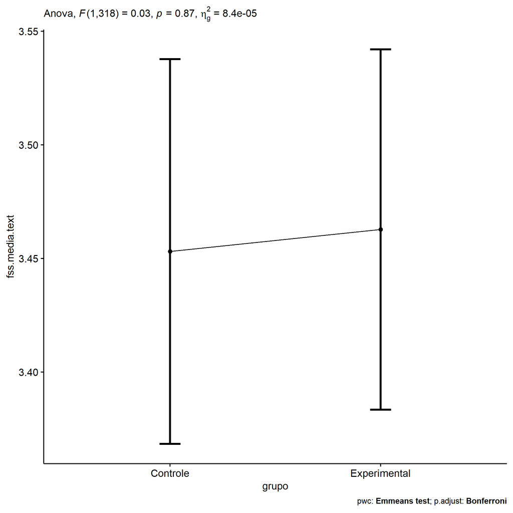

```r
if (!is.null(nrow(plots[["grupo"]]$data)))
  plots[["grupo"]] + ggplot2::scale_color_manual(values = color[["grupo"]])
```

```r
plots <- oneWayAncovaBoxPlots(
  wdat, "fss.media.text", "grupo", aov, pwc, covar = "dfs.media.text",
  theme = "classic", color = color[["grupo"]],
  subtitle = which(aov$Effect == "grupo"))
```

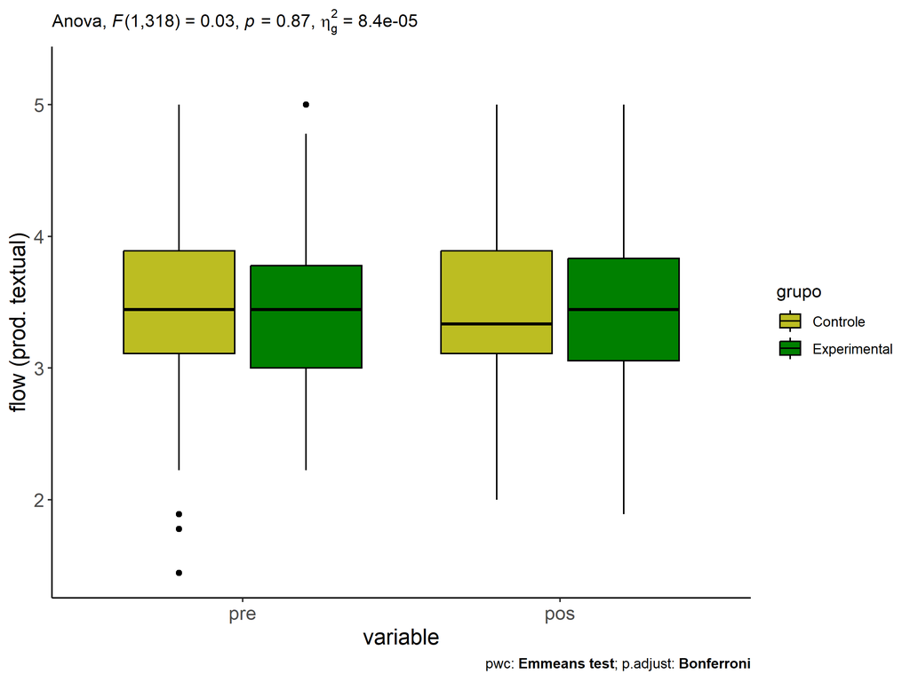

```r
if (length(unique(wdat[["grupo"]])) > 1)
  plots[["grupo"]] + ggplot2::ylab("flow (prod. textual)") + ggplot2::scale_x_discrete(labels=c('pre', 'pos'))
```

```r
if (length(unique(wdat.long[["grupo"]])) > 1)
  plots <- oneWayAncovaBoxPlots(
    wdat.long, "flow.text", "grupo", aov, pwc.long, pre.post = "time",
    theme = "classic", color = color$prepost)
```

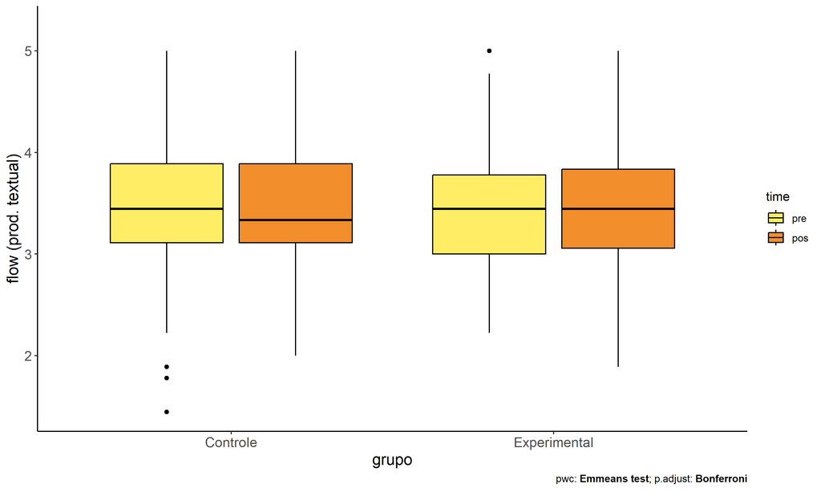

```r
if (length(unique(wdat.long[["grupo"]])) > 1)
  plots[["grupo"]] + ggplot2::ylab("flow (prod. textual)")
```

### Checking linearity assumption

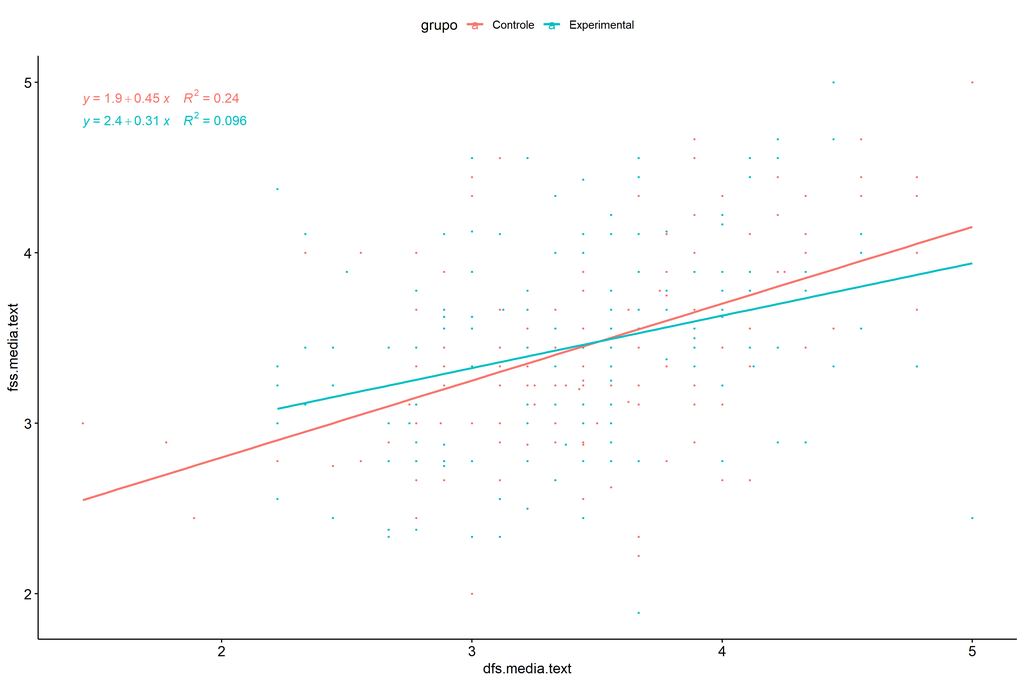

```r
ggscatter(wdat, x = "dfs.media.text", y = "fss.media.text", size = 0.5,
          color = "grupo", add = "reg.line")+
  stat_regline_equation(
    aes(label =  paste(..eq.label.., ..rr.label.., sep = "~~~~"), color = grupo)
  )
```

### Checking normality and homogeneity

```r
res <- augment(lm(fss.media.text ~ dfs.media.text + grupo, data = wdat))
```

```r
shapiro_test(res$.resid)
```

```
## # A tibble: 1 × 3
##   variable   statistic p.value
##   <chr>          <dbl>   <dbl>
## 1 res$.resid     0.994   0.296
```

```r
levene_test(res, .resid ~ grupo)
```

```
## # A tibble: 1 × 4
##     df1   df2 statistic     p
##   <int> <int>     <dbl> <dbl>
## 1     1   319     0.383 0.536
```

# ANCOVA and Pairwise for two factors **grupo:Sexo**

## Without remove non-normal data

```r
pdat = remove_group_data(dat[!is.na(dat[["grupo"]]) & !is.na(dat[["Sexo"]]),], "fss.media.text", c("grupo","Sexo"))

pdat.long <- rbind(pdat[,c("id","grupo","Sexo")], pdat[,c("id","grupo","Sexo")])
pdat.long[["time"]] <- c(rep("pre", nrow(pdat)), rep("pos", nrow(pdat)))
pdat.long[["time"]] <- factor(pdat.long[["time"]], c("pre","pos"))
pdat.long[["flow.text"]] <- c(pdat[["dfs.media.text"]], pdat[["fss.media.text"]])

aov = anova_test(pdat, fss.media.text ~ dfs.media.text + grupo*Sexo)
laov[["grupo:Sexo"]] <- get_anova_table(aov)
```

```r
pwcs <- list()
pwcs[["Sexo"]] <- emmeans_test(
  group_by(pdat, grupo), fss.media.text ~ Sexo,
  covariate = dfs.media.text, p.adjust.method = "bonferroni")
pwcs[["grupo"]] <- emmeans_test(
  group_by(pdat, Sexo), fss.media.text ~ grupo,
  covariate = dfs.media.text, p.adjust.method = "bonferroni")

pwc <- plyr::rbind.fill(pwcs[["grupo"]], pwcs[["Sexo"]])
pwc <- pwc[,c("grupo","Sexo", colnames(pwc)[!colnames(pwc) %in% c("grupo","Sexo")])]
```

```r
pwc.long <- emmeans_test(dplyr::group_by_at(pdat.long, c("grupo","Sexo")),
                         flow.text ~ time,
                         p.adjust.method = "bonferroni")
lpwc[["grupo:Sexo"]] <- plyr::rbind.fill(pwc, pwc.long)
```

```r
ds <- get.descriptives(pdat, "fss.media.text", c("grupo","Sexo"), covar = "dfs.media.text")
ds <- merge(ds[ds$variable != "dfs.media.text",],
            ds[ds$variable == "dfs.media.text", !colnames(ds) %in% c("variable")],
            by = c("grupo","Sexo"), all.x = T, suffixes = c("", ".dfs.media.text"))
ds <- merge(get_emmeans(pwcs[["grupo"]]), ds, by = c("grupo","Sexo"), suffixes = c(".emms", ""))
ds <- ds[,c("grupo","Sexo","n","mean.dfs.media.text","se.dfs.media.text","mean","se","emmean","se.emms")]

colnames(ds) <- c("grupo","Sexo", "N", paste0(c("M","SE")," (pre)"),
                  paste0(c("M","SE"), " (unadj)"), paste0(c("M", "SE"), " (adj)"))

lemms[["grupo:Sexo"]] <- ds
```

## Computing ANCOVA and PairWise After removing non-normal data (OK)

```r
wdat = pdat

res = residuals(lm(fss.media.text ~ dfs.media.text + grupo*Sexo, data = wdat))
non.normal = getNonNormal(res, wdat$id, plimit = 0.05)

wdat = wdat[!wdat$id %in% non.normal,]

wdat.long <- rbind(wdat[,c("id","grupo","Sexo")], wdat[,c("id","grupo","Sexo")])
wdat.long[["time"]] <- c(rep("pre", nrow(wdat)), rep("pos", nrow(wdat)))
wdat.long[["time"]] <- factor(wdat.long[["time"]], c("pre","pos"))
wdat.long[["flow.text"]] <- c(wdat[["dfs.media.text"]], wdat[["fss.media.text"]])


ldat[["grupo:Sexo"]] = wdat

(non.normal)
```

```
## [1] "P2896"
```

```r
aov = anova_test(wdat, fss.media.text ~ dfs.media.text + grupo*Sexo)
laov[["grupo:Sexo"]] <- merge(get_anova_table(aov), laov[["grupo:Sexo"]], by="Effect", suffixes = c("","'"))

(df = get_anova_table(aov))
```

```
## ANOVA Table (type II tests)
##
##           Effect DFn DFd      F        p p<.05      ges
## 1 dfs.media.text   1 316 57.191 4.34e-13     * 1.53e-01
## 2          grupo   1 316  0.012 9.13e-01       3.77e-05
## 3           Sexo   1 316  0.517 4.73e-01       2.00e-03
## 4     grupo:Sexo   1 316  2.642 1.05e-01       8.00e-03
```

| Effect | DFn | DFd | F | p | p<.05 | ges |
| --- | --- | --- | --- | --- | --- | --- |
| dfs.media.text | 1 | 316 | 57.191 | 0.000 | * | 0.153 |
| grupo | 1 | 316 | 0.012 | 0.913 |  | 0.000 |
| Sexo | 1 | 316 | 0.517 | 0.473 |  | 0.002 |
| grupo:Sexo | 1 | 316 | 2.642 | 0.105 |  | 0.008 |

```r
pwcs <- list()
pwcs[["Sexo"]] <- emmeans_test(
  group_by(wdat, grupo), fss.media.text ~ Sexo,
  covariate = dfs.media.text, p.adjust.method = "bonferroni")
pwcs[["grupo"]] <- emmeans_test(
  group_by(wdat, Sexo), fss.media.text ~ grupo,
  covariate = dfs.media.text, p.adjust.method = "bonferroni")

pwc <- plyr::rbind.fill(pwcs[["grupo"]], pwcs[["Sexo"]])
pwc <- pwc[,c("grupo","Sexo", colnames(pwc)[!colnames(pwc) %in% c("grupo","Sexo")])]
```

| grupo | Sexo | term | .y. | group1 | group2 | df | statistic | p | p.adj | p.adj.signif |
| --- | --- | --- | --- | --- | --- | --- | --- | --- | --- | --- |
|  | F | dfs.media.text*grupo | fss.media.text | Controle | Experimental | 316 | 1.076 | 0.283 | 0.283 | ns |
|  | M | dfs.media.text*grupo | fss.media.text | Controle | Experimental | 316 | -1.221 | 0.223 | 0.223 | ns |
| Controle |  | dfs.media.text*Sexo | fss.media.text | F | M | 316 | 1.677 | 0.095 | 0.095 | ns |
| Experimental |  | dfs.media.text*Sexo | fss.media.text | F | M | 316 | -0.573 | 0.567 | 0.567 | ns |

```r
pwc.long <- emmeans_test(dplyr::group_by_at(wdat.long, c("grupo","Sexo")),
                         flow.text ~ time,
                         p.adjust.method = "bonferroni")
lpwc[["grupo:Sexo"]] <- merge(plyr::rbind.fill(pwc, pwc.long), lpwc[["grupo:Sexo"]], by=c("grupo","Sexo","term",".y.","group1","group2"), suffixes = c("","'"))
```

| grupo | Sexo | term | .y. | group1 | group2 | df | statistic | p | p.adj | p.adj.signif |
| --- | --- | --- | --- | --- | --- | --- | --- | --- | --- | --- |
| Controle | F | time | flow.text | pre | pos | 634 | 0.125 | 0.901 | 0.901 | ns |
| Controle | M | time | flow.text | pre | pos | 634 | 0.200 | 0.841 | 0.841 | ns |
| Experimental | F | time | flow.text | pre | pos | 634 | 0.189 | 0.850 | 0.850 | ns |
| Experimental | M | time | flow.text | pre | pos | 634 | -1.233 | 0.218 | 0.218 | ns |

```r
ds <- get.descriptives(wdat, "fss.media.text", c("grupo","Sexo"), covar = "dfs.media.text")
ds <- merge(ds[ds$variable != "dfs.media.text",],
            ds[ds$variable == "dfs.media.text", !colnames(ds) %in% c("variable")],
            by = c("grupo","Sexo"), all.x = T, suffixes = c("", ".dfs.media.text"))
ds <- merge(get_emmeans(pwcs[["grupo"]]), ds, by = c("grupo","Sexo"), suffixes = c(".emms", ""))
ds <- ds[,c("grupo","Sexo","n","mean.dfs.media.text","se.dfs.media.text","mean","se","emmean","se.emms")]

colnames(ds) <- c("grupo","Sexo", "N", paste0(c("M","SE")," (pre)"),
                  paste0(c("M","SE"), " (unadj)"), paste0(c("M", "SE"), " (adj)"))

lemms[["grupo:Sexo"]] <- merge(ds, lemms[["grupo:Sexo"]], by=c("grupo","Sexo"), suffixes = c("","'"))
```

| grupo | Sexo | N | M (pre) | SE (pre) | M (unadj) | SE (unadj) | M (adj) | SE (adj) |
| --- | --- | --- | --- | --- | --- | --- | --- | --- |
| Controle | F | 70 | 3.604 | 0.076 | 3.591 | 0.067 | 3.531 | 0.063 |
| Controle | M | 80 | 3.382 | 0.069 | 3.363 | 0.064 | 3.386 | 0.059 |
| Experimental | F | 91 | 3.466 | 0.057 | 3.450 | 0.065 | 3.441 | 0.055 |
| Experimental | M | 80 | 3.332 | 0.068 | 3.446 | 0.058 | 3.487 | 0.059 |

### Plots for ancova

```r
plots <- twoWayAncovaPlots(
  wdat, "fss.media.text", c("grupo","Sexo"), aov, pwcs, addParam = c("mean_se"),
  font.label.size=10, step.increase=0.05, p.label="p.adj",
  subtitle = which(aov$Effect == "grupo:Sexo"))
```

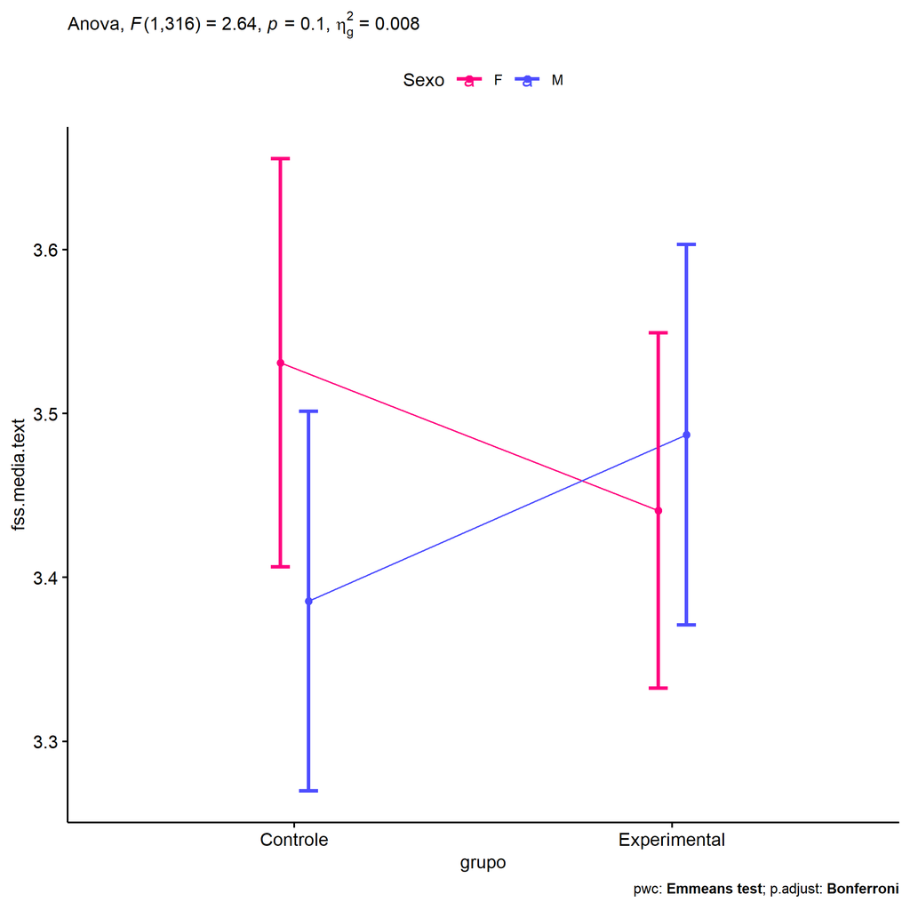

```r
if (!is.null(plots[["grupo"]]))
  plots[["grupo"]] + ggplot2::scale_color_manual(values = color[["Sexo"]])
```

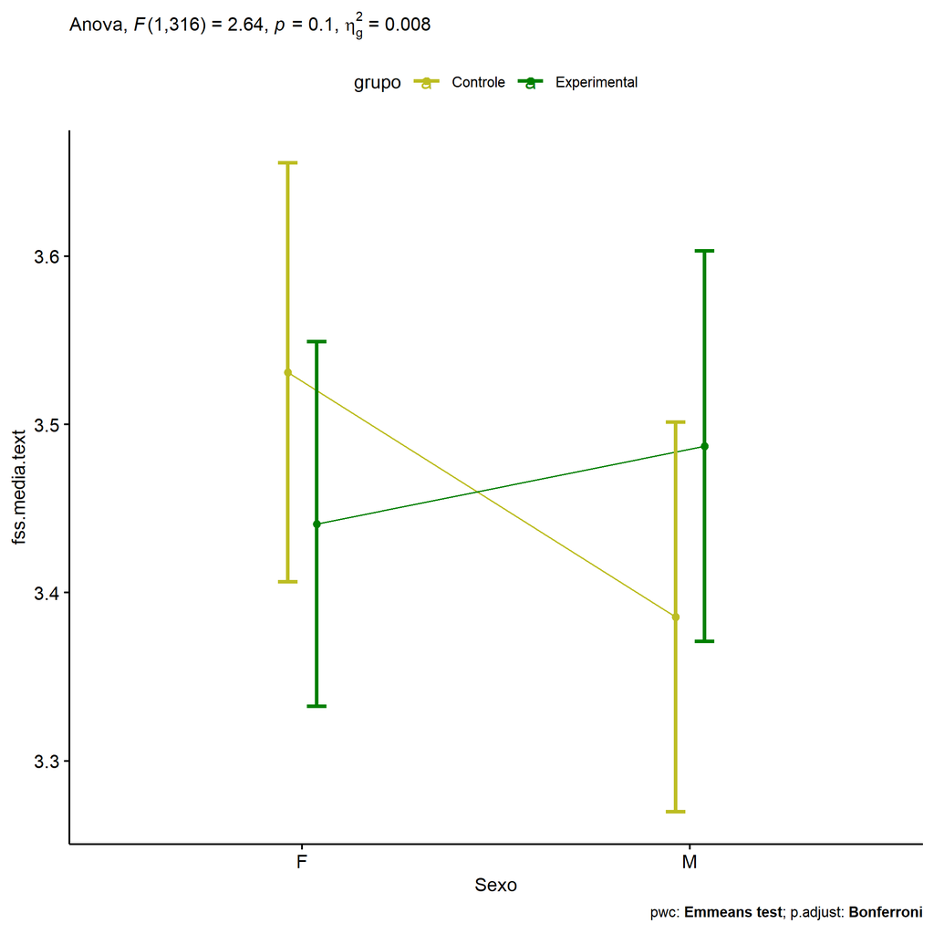

```r
if (!is.null(plots[["Sexo"]]))
  plots[["Sexo"]] + ggplot2::scale_color_manual(values = color[["grupo"]])
```

```r
plots <- twoWayAncovaBoxPlots(
  wdat, "fss.media.text", c("grupo","Sexo"), aov, pwcs, covar = "dfs.media.text",
  theme = "classic", color = color[["grupo:Sexo"]],
  subtitle = which(aov$Effect == "grupo:Sexo"))
```

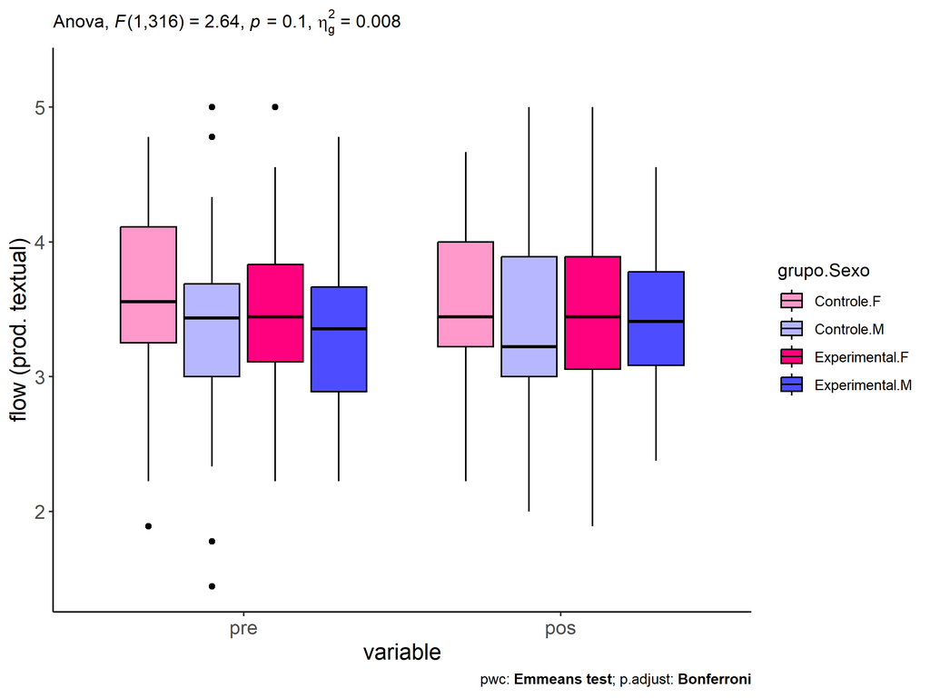

```r
plots[["grupo:Sexo"]] + ggplot2::ylab("flow (prod. textual)") + ggplot2::scale_x_discrete(labels=c('pre', 'pos'))
```

```r
plots <- twoWayAncovaBoxPlots(
  wdat.long, "flow.text", c("grupo","Sexo"), aov, pwc.long, pre.post = "time",
  theme = "classic", color = color$prepost)
```

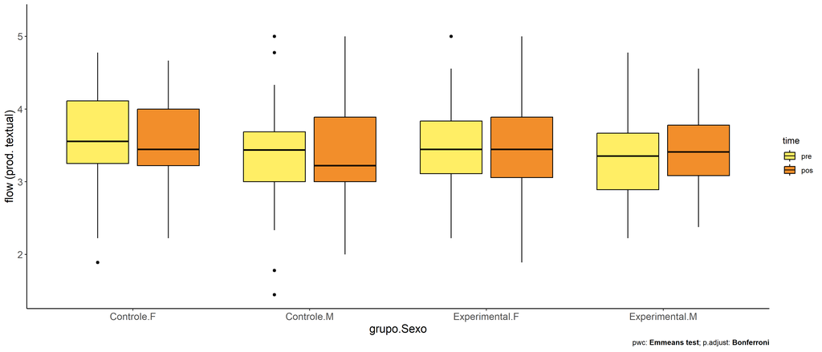

```r
plots[["grupo:Sexo"]] + ggplot2::ylab("flow (prod. textual)")
```

### Checking linearity assumption

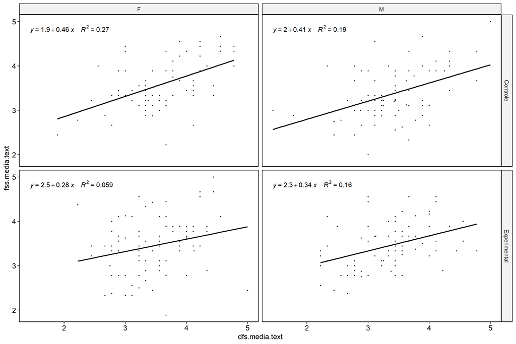

```r
ggscatter(wdat, x = "dfs.media.text", y = "fss.media.text", size = 0.5,
          facet.by = c("grupo","Sexo"), add = "reg.line")+
  stat_regline_equation(
    aes(label =  paste(..eq.label.., ..rr.label.., sep = "~~~~"))
  )
```

### Checking normality and homogeneity

```r
res <- augment(lm(fss.media.text ~ dfs.media.text + grupo*Sexo, data = wdat))
```

```r
shapiro_test(res$.resid)
```

```
## # A tibble: 1 × 3
##   variable   statistic p.value
##   <chr>          <dbl>   <dbl>
## 1 res$.resid     0.995   0.308
```

```r
levene_test(res, .resid ~ grupo*Sexo)
```

```
## # A tibble: 1 × 4
##     df1   df2 statistic     p
##   <int> <int>     <dbl> <dbl>
## 1     3   317      1.35 0.258
```

# ANCOVA and Pairwise for two factors **grupo:Zona**

## Without remove non-normal data

```r
pdat = remove_group_data(dat[!is.na(dat[["grupo"]]) & !is.na(dat[["Zona"]]),], "fss.media.text", c("grupo","Zona"))

pdat.long <- rbind(pdat[,c("id","grupo","Zona")], pdat[,c("id","grupo","Zona")])
pdat.long[["time"]] <- c(rep("pre", nrow(pdat)), rep("pos", nrow(pdat)))
pdat.long[["time"]] <- factor(pdat.long[["time"]], c("pre","pos"))
pdat.long[["flow.text"]] <- c(pdat[["dfs.media.text"]], pdat[["fss.media.text"]])

aov = anova_test(pdat, fss.media.text ~ dfs.media.text + grupo*Zona)
laov[["grupo:Zona"]] <- get_anova_table(aov)
```

```r
pwcs <- list()
pwcs[["Zona"]] <- emmeans_test(
  group_by(pdat, grupo), fss.media.text ~ Zona,
  covariate = dfs.media.text, p.adjust.method = "bonferroni")
pwcs[["grupo"]] <- emmeans_test(
  group_by(pdat, Zona), fss.media.text ~ grupo,
  covariate = dfs.media.text, p.adjust.method = "bonferroni")

pwc <- plyr::rbind.fill(pwcs[["grupo"]], pwcs[["Zona"]])
pwc <- pwc[,c("grupo","Zona", colnames(pwc)[!colnames(pwc) %in% c("grupo","Zona")])]
```

```r
pwc.long <- emmeans_test(dplyr::group_by_at(pdat.long, c("grupo","Zona")),
                         flow.text ~ time,
                         p.adjust.method = "bonferroni")
lpwc[["grupo:Zona"]] <- plyr::rbind.fill(pwc, pwc.long)
```

```r
ds <- get.descriptives(pdat, "fss.media.text", c("grupo","Zona"), covar = "dfs.media.text")
ds <- merge(ds[ds$variable != "dfs.media.text",],
            ds[ds$variable == "dfs.media.text", !colnames(ds) %in% c("variable")],
            by = c("grupo","Zona"), all.x = T, suffixes = c("", ".dfs.media.text"))
ds <- merge(get_emmeans(pwcs[["grupo"]]), ds, by = c("grupo","Zona"), suffixes = c(".emms", ""))
ds <- ds[,c("grupo","Zona","n","mean.dfs.media.text","se.dfs.media.text","mean","se","emmean","se.emms")]

colnames(ds) <- c("grupo","Zona", "N", paste0(c("M","SE")," (pre)"),
                  paste0(c("M","SE"), " (unadj)"), paste0(c("M", "SE"), " (adj)"))

lemms[["grupo:Zona"]] <- ds
```

## Computing ANCOVA and PairWise After removing non-normal data (OK)

```r
wdat = pdat

res = residuals(lm(fss.media.text ~ dfs.media.text + grupo*Zona, data = wdat))
non.normal = getNonNormal(res, wdat$id, plimit = 0.05)

wdat = wdat[!wdat$id %in% non.normal,]

wdat.long <- rbind(wdat[,c("id","grupo","Zona")], wdat[,c("id","grupo","Zona")])
wdat.long[["time"]] <- c(rep("pre", nrow(wdat)), rep("pos", nrow(wdat)))
wdat.long[["time"]] <- factor(wdat.long[["time"]], c("pre","pos"))
wdat.long[["flow.text"]] <- c(wdat[["dfs.media.text"]], wdat[["fss.media.text"]])


ldat[["grupo:Zona"]] = wdat

(non.normal)
```

```
## [1] "P2896"
```

```r
aov = anova_test(wdat, fss.media.text ~ dfs.media.text + grupo*Zona)
laov[["grupo:Zona"]] <- merge(get_anova_table(aov), laov[["grupo:Zona"]], by="Effect", suffixes = c("","'"))

(df = get_anova_table(aov))
```

```
## ANOVA Table (type II tests)
##
##           Effect DFn DFd      F        p p<.05      ges
## 1 dfs.media.text   1 250 47.773 3.96e-11     * 0.160000
## 2          grupo   1 250  0.083 7.73e-01       0.000334
## 3           Zona   1 250  2.340 1.27e-01       0.009000
## 4     grupo:Zona   1 250  0.241 6.24e-01       0.000964
```

| Effect | DFn | DFd | F | p | p<.05 | ges |
| --- | --- | --- | --- | --- | --- | --- |
| dfs.media.text | 1 | 250 | 47.773 | 0.000 | * | 0.160 |
| grupo | 1 | 250 | 0.083 | 0.773 |  | 0.000 |
| Zona | 1 | 250 | 2.340 | 0.127 |  | 0.009 |
| grupo:Zona | 1 | 250 | 0.241 | 0.624 |  | 0.001 |

```r
pwcs <- list()
pwcs[["Zona"]] <- emmeans_test(
  group_by(wdat, grupo), fss.media.text ~ Zona,
  covariate = dfs.media.text, p.adjust.method = "bonferroni")
pwcs[["grupo"]] <- emmeans_test(
  group_by(wdat, Zona), fss.media.text ~ grupo,
  covariate = dfs.media.text, p.adjust.method = "bonferroni")

pwc <- plyr::rbind.fill(pwcs[["grupo"]], pwcs[["Zona"]])
pwc <- pwc[,c("grupo","Zona", colnames(pwc)[!colnames(pwc) %in% c("grupo","Zona")])]
```

| grupo | Zona | term | .y. | group1 | group2 | df | statistic | p | p.adj | p.adj.signif |
| --- | --- | --- | --- | --- | --- | --- | --- | --- | --- | --- |
|  | Rural | dfs.media.text*grupo | fss.media.text | Controle | Experimental | 250 | -0.014 | 0.989 | 0.989 | ns |
|  | Urbana | dfs.media.text*grupo | fss.media.text | Controle | Experimental | 250 | 0.570 | 0.569 | 0.569 | ns |
| Controle |  | dfs.media.text*Zona | fss.media.text | Rural | Urbana | 250 | 0.664 | 0.507 | 0.507 | ns |
| Experimental |  | dfs.media.text*Zona | fss.media.text | Rural | Urbana | 250 | 1.464 | 0.144 | 0.144 | ns |

```r
pwc.long <- emmeans_test(dplyr::group_by_at(wdat.long, c("grupo","Zona")),
                         flow.text ~ time,
                         p.adjust.method = "bonferroni")
lpwc[["grupo:Zona"]] <- merge(plyr::rbind.fill(pwc, pwc.long), lpwc[["grupo:Zona"]], by=c("grupo","Zona","term",".y.","group1","group2"), suffixes = c("","'"))
```

| grupo | Zona | term | .y. | group1 | group2 | df | statistic | p | p.adj | p.adj.signif |
| --- | --- | --- | --- | --- | --- | --- | --- | --- | --- | --- |
| Controle | Rural | time | flow.text | pre | pos | 502 | 0.398 | 0.691 | 0.691 | ns |
| Controle | Urbana | time | flow.text | pre | pos | 502 | -0.269 | 0.788 | 0.788 | ns |
| Experimental | Rural | time | flow.text | pre | pos | 502 | -1.003 | 0.316 | 0.316 | ns |
| Experimental | Urbana | time | flow.text | pre | pos | 502 | 0.318 | 0.751 | 0.751 | ns |

```r
ds <- get.descriptives(wdat, "fss.media.text", c("grupo","Zona"), covar = "dfs.media.text")
ds <- merge(ds[ds$variable != "dfs.media.text",],
            ds[ds$variable == "dfs.media.text", !colnames(ds) %in% c("variable")],
            by = c("grupo","Zona"), all.x = T, suffixes = c("", ".dfs.media.text"))
ds <- merge(get_emmeans(pwcs[["grupo"]]), ds, by = c("grupo","Zona"), suffixes = c(".emms", ""))
ds <- ds[,c("grupo","Zona","n","mean.dfs.media.text","se.dfs.media.text","mean","se","emmean","se.emms")]

colnames(ds) <- c("grupo","Zona", "N", paste0(c("M","SE")," (pre)"),
                  paste0(c("M","SE"), " (unadj)"), paste0(c("M", "SE"), " (adj)"))

lemms[["grupo:Zona"]] <- merge(ds, lemms[["grupo:Zona"]], by=c("grupo","Zona"), suffixes = c("","'"))
```

| grupo | Zona | N | M (pre) | SE (pre) | M (unadj) | SE (unadj) | M (adj) | SE (adj) |
| --- | --- | --- | --- | --- | --- | --- | --- | --- |
| Controle | Rural | 99 | 3.580 | 0.060 | 3.547 | 0.057 | 3.498 | 0.053 |
| Controle | Urbana | 30 | 3.344 | 0.133 | 3.385 | 0.109 | 3.426 | 0.095 |
| Experimental | Rural | 85 | 3.384 | 0.062 | 3.474 | 0.059 | 3.499 | 0.056 |
| Experimental | Urbana | 41 | 3.360 | 0.076 | 3.320 | 0.089 | 3.355 | 0.081 |

### Plots for ancova

```r
plots <- twoWayAncovaPlots(
  wdat, "fss.media.text", c("grupo","Zona"), aov, pwcs, addParam = c("mean_se"),
  font.label.size=10, step.increase=0.05, p.label="p.adj",
  subtitle = which(aov$Effect == "grupo:Zona"))
```

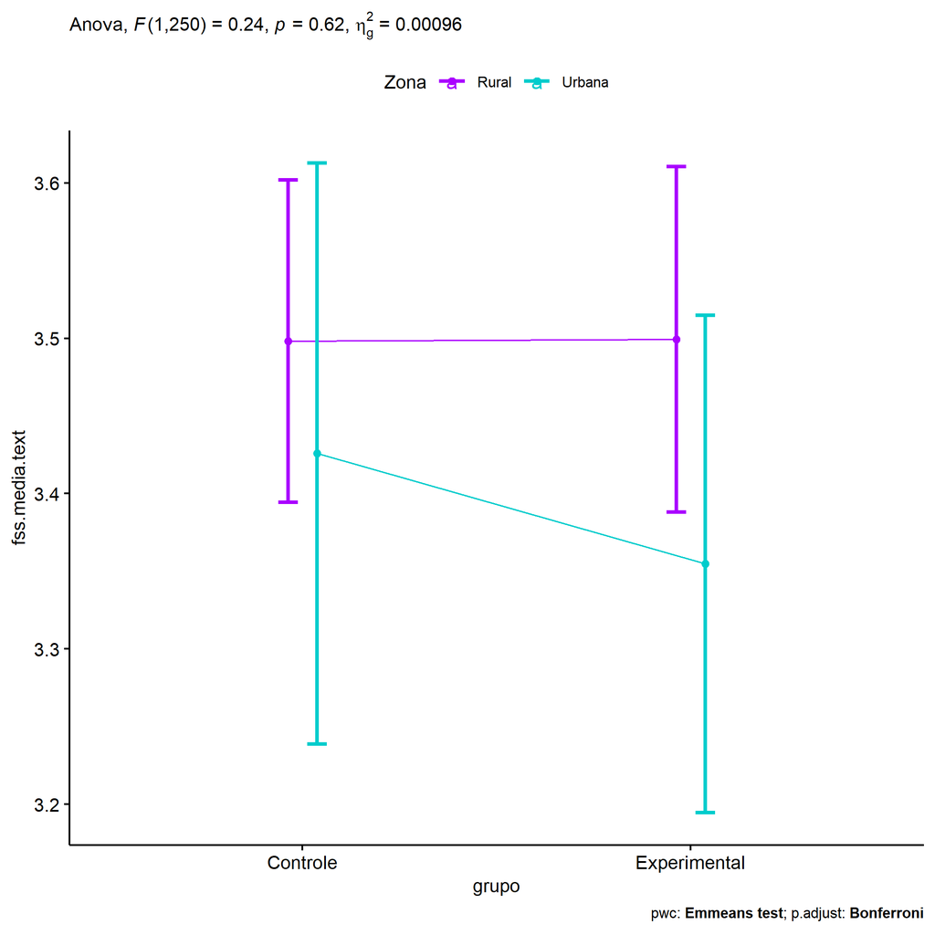

```r
if (!is.null(plots[["grupo"]]))
  plots[["grupo"]] + ggplot2::scale_color_manual(values = color[["Zona"]])
```

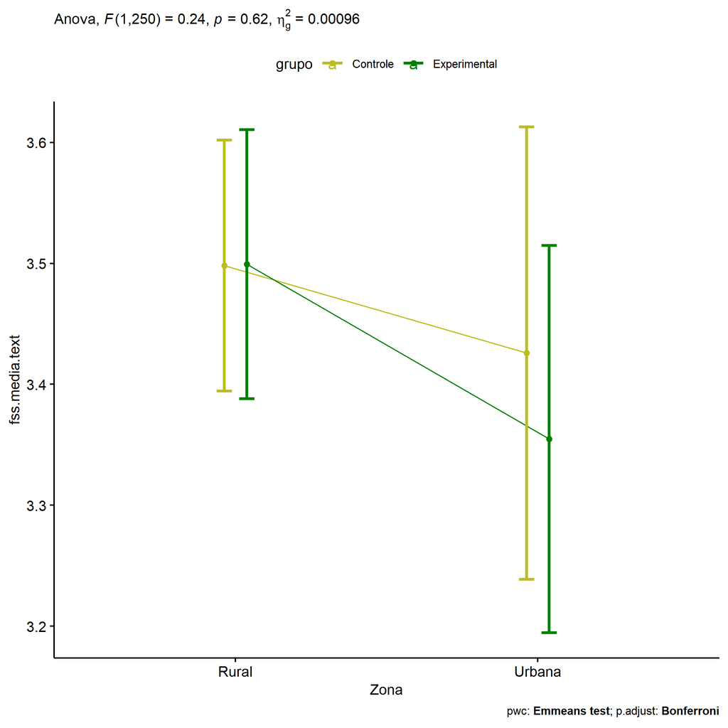

```r
if (!is.null(plots[["Zona"]]))
  plots[["Zona"]] + ggplot2::scale_color_manual(values = color[["grupo"]])
```

```r
plots <- twoWayAncovaBoxPlots(
  wdat, "fss.media.text", c("grupo","Zona"), aov, pwcs, covar = "dfs.media.text",
  theme = "classic", color = color[["grupo:Zona"]],
  subtitle = which(aov$Effect == "grupo:Zona"))
```

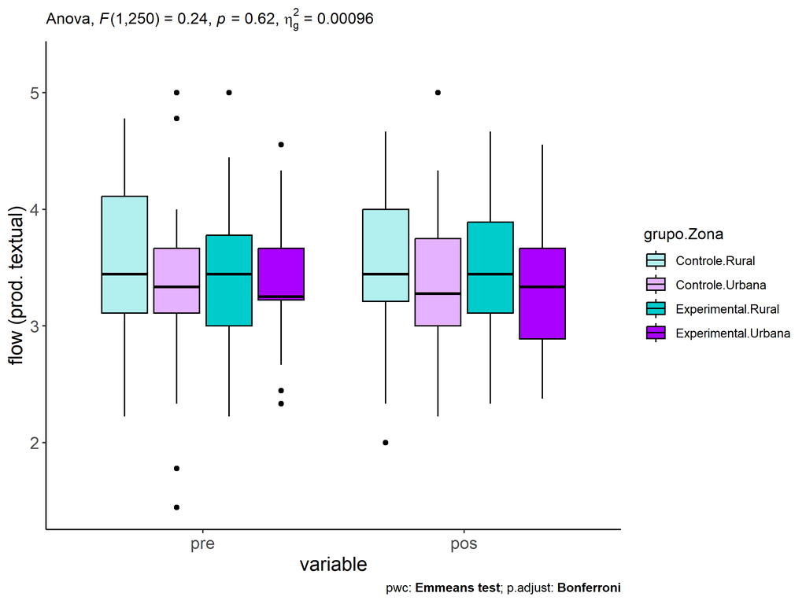

```r
plots[["grupo:Zona"]] + ggplot2::ylab("flow (prod. textual)") + ggplot2::scale_x_discrete(labels=c('pre', 'pos'))
```

```r
plots <- twoWayAncovaBoxPlots(
  wdat.long, "flow.text", c("grupo","Zona"), aov, pwc.long, pre.post = "time",
  theme = "classic", color = color$prepost)
```

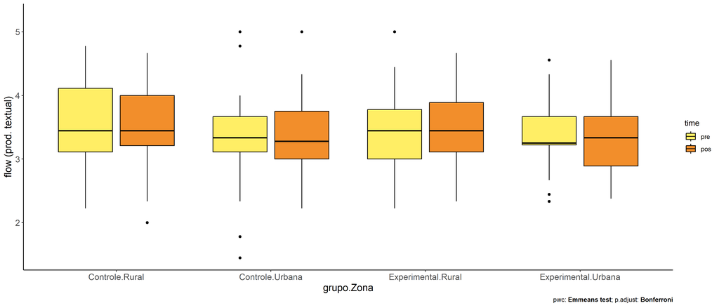

```r
plots[["grupo:Zona"]] + ggplot2::ylab("flow (prod. textual)")
```

### Checking linearity assumption

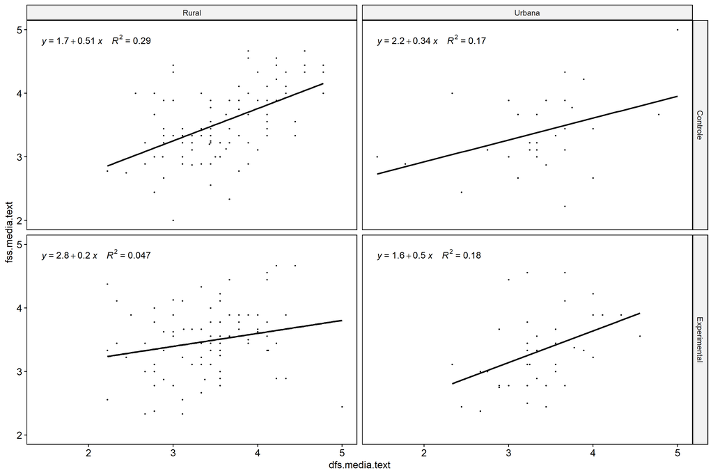

```r
ggscatter(wdat, x = "dfs.media.text", y = "fss.media.text", size = 0.5,
          facet.by = c("grupo","Zona"), add = "reg.line")+
  stat_regline_equation(
    aes(label =  paste(..eq.label.., ..rr.label.., sep = "~~~~"))
  )
```

### Checking normality and homogeneity

```r
res <- augment(lm(fss.media.text ~ dfs.media.text + grupo*Zona, data = wdat))
```

```r
shapiro_test(res$.resid)
```

```
## # A tibble: 1 × 3
##   variable   statistic p.value
##   <chr>          <dbl>   <dbl>
## 1 res$.resid     0.996   0.711
```

```r
levene_test(res, .resid ~ grupo*Zona)
```

```
## # A tibble: 1 × 4
##     df1   df2 statistic     p
##   <int> <int>     <dbl> <dbl>
## 1     3   251     0.229 0.876
```

# ANCOVA and Pairwise for two factors **grupo:Cor.Raca**

## Without remove non-normal data

```r
pdat = remove_group_data(dat[!is.na(dat[["grupo"]]) & !is.na(dat[["Cor.Raca"]]),], "fss.media.text", c("grupo","Cor.Raca"))
pdat.long <- rbind(pdat[,c("id","grupo","Cor.Raca")], pdat[,c("id","grupo","Cor.Raca")])
pdat.long[["time"]] <- c(rep("pre", nrow(pdat)), rep("pos", nrow(pdat)))
pdat.long[["time"]] <- factor(pdat.long[["time"]], c("pre","pos"))
pdat.long[["flow.text"]] <- c(pdat[["dfs.media.text"]], pdat[["fss.media.text"]])

aov = anova_test(pdat, fss.media.text ~ dfs.media.text + grupo*Cor.Raca)
laov[["grupo:Cor.Raca"]] <- get_anova_table(aov)
```

```r
pwcs <- list()
pwcs[["Cor.Raca"]] <- emmeans_test(
  group_by(pdat, grupo), fss.media.text ~ Cor.Raca,
  covariate = dfs.media.text, p.adjust.method = "bonferroni")
pwcs[["grupo"]] <- emmeans_test(
  group_by(pdat, Cor.Raca), fss.media.text ~ grupo,
  covariate = dfs.media.text, p.adjust.method = "bonferroni")

pwc <- plyr::rbind.fill(pwcs[["grupo"]], pwcs[["Cor.Raca"]])
pwc <- pwc[,c("grupo","Cor.Raca", colnames(pwc)[!colnames(pwc) %in% c("grupo","Cor.Raca")])]
```

```r
pwc.long <- emmeans_test(dplyr::group_by_at(pdat.long, c("grupo","Cor.Raca")),
                         flow.text ~ time,
                         p.adjust.method = "bonferroni")
lpwc[["grupo:Cor.Raca"]] <- plyr::rbind.fill(pwc, pwc.long)
```

```r
ds <- get.descriptives(pdat, "fss.media.text", c("grupo","Cor.Raca"), covar = "dfs.media.text")
ds <- merge(ds[ds$variable != "dfs.media.text",],
            ds[ds$variable == "dfs.media.text", !colnames(ds) %in% c("variable")],
            by = c("grupo","Cor.Raca"), all.x = T, suffixes = c("", ".dfs.media.text"))
ds <- merge(get_emmeans(pwcs[["grupo"]]), ds, by = c("grupo","Cor.Raca"), suffixes = c(".emms", ""))
ds <- ds[,c("grupo","Cor.Raca","n","mean.dfs.media.text","se.dfs.media.text","mean","se","emmean","se.emms")]

colnames(ds) <- c("grupo","Cor.Raca", "N", paste0(c("M","SE")," (pre)"),
                  paste0(c("M","SE"), " (unadj)"), paste0(c("M", "SE"), " (adj)"))

lemms[["grupo:Cor.Raca"]] <- ds
```

## Computing ANCOVA and PairWise After removing non-normal data (OK)

```r
wdat = pdat

res = residuals(lm(fss.media.text ~ dfs.media.text + grupo*Cor.Raca, data = wdat))
non.normal = getNonNormal(res, wdat$id, plimit = 0.05)

wdat = wdat[!wdat$id %in% non.normal,]

wdat.long <- rbind(wdat[,c("id","grupo","Cor.Raca")], wdat[,c("id","grupo","Cor.Raca")])
wdat.long[["time"]] <- c(rep("pre", nrow(wdat)), rep("pos", nrow(wdat)))
wdat.long[["time"]] <- factor(wdat.long[["time"]], c("pre","pos"))
wdat.long[["flow.text"]] <- c(wdat[["dfs.media.text"]], wdat[["fss.media.text"]])


ldat[["grupo:Cor.Raca"]] = wdat

(non.normal)
```

[output not shown]

```r
aov = anova_test(wdat, fss.media.text ~ dfs.media.text + grupo*Cor.Raca)
laov[["grupo:Cor.Raca"]] <- merge(get_anova_table(aov), laov[["grupo:Cor.Raca"]], by="Effect", suffixes = c("","'"))

(df = get_anova_table(aov))
```

```
## ANOVA Table (type II tests)
##
##           Effect DFn DFd      F        p p<.05      ges
## 1 dfs.media.text   1 129 26.591 9.22e-07     * 0.171000
## 2          grupo   1 129  0.071 7.90e-01       0.000549
## 3       Cor.Raca   2 129  0.137 8.72e-01       0.002000
## 4 grupo:Cor.Raca   1 129  1.801 1.82e-01       0.014000
```

| Effect | DFn | DFd | F | p | p<.05 | ges |
| --- | --- | --- | --- | --- | --- | --- |
| dfs.media.text | 1 | 129 | 26.591 | 0.000 | * | 0.171 |
| grupo | 1 | 129 | 0.071 | 0.790 |  | 0.001 |
| Cor.Raca | 2 | 129 | 0.137 | 0.872 |  | 0.002 |
| grupo:Cor.Raca | 1 | 129 | 1.801 | 0.182 |  | 0.014 |

```r
pwcs <- list()
pwcs[["Cor.Raca"]] <- emmeans_test(
  group_by(wdat, grupo), fss.media.text ~ Cor.Raca,
  covariate = dfs.media.text, p.adjust.method = "bonferroni")
pwcs[["grupo"]] <- emmeans_test(
  group_by(wdat, Cor.Raca), fss.media.text ~ grupo,
  covariate = dfs.media.text, p.adjust.method = "bonferroni")

pwc <- plyr::rbind.fill(pwcs[["grupo"]], pwcs[["Cor.Raca"]])
pwc <- pwc[,c("grupo","Cor.Raca", colnames(pwc)[!colnames(pwc) %in% c("grupo","Cor.Raca")])]
```

| grupo | Cor.Raca | term | .y. | group1 | group2 | df | statistic | p | p.adj | p.adj.signif |
| --- | --- | --- | --- | --- | --- | --- | --- | --- | --- | --- |
|  | Branca | dfs.media.text*grupo | fss.media.text | Controle | Experimental | 129 | 0.950 | 0.344 | 0.344 | ns |
|  | Indígena | dfs.media.text*grupo | fss.media.text | Controle | Experimental |  |  |  |  |  |
|  | Parda | dfs.media.text*grupo | fss.media.text | Controle | Experimental | 129 | -0.969 | 0.334 | 0.334 | ns |
| Controle |  | dfs.media.text*Cor.Raca | fss.media.text | Branca | Indígena |  |  |  |  |  |
| Controle |  | dfs.media.text*Cor.Raca | fss.media.text | Branca | Parda | 129 | 0.552 | 0.582 | 0.582 | ns |
| Controle |  | dfs.media.text*Cor.Raca | fss.media.text | Indígena | Parda |  |  |  |  |  |
| Experimental |  | dfs.media.text*Cor.Raca | fss.media.text | Branca | Indígena | 129 | -0.704 | 0.483 | 1.000 | ns |
| Experimental |  | dfs.media.text*Cor.Raca | fss.media.text | Branca | Parda | 129 | -1.335 | 0.184 | 0.552 | ns |
| Experimental |  | dfs.media.text*Cor.Raca | fss.media.text | Indígena | Parda | 129 | -0.360 | 0.719 | 1.000 | ns |

```r
pwc.long <- emmeans_test(dplyr::group_by_at(wdat.long, c("grupo","Cor.Raca")),
                         flow.text ~ time,
                         p.adjust.method = "bonferroni")
lpwc[["grupo:Cor.Raca"]] <- merge(plyr::rbind.fill(pwc, pwc.long), lpwc[["grupo:Cor.Raca"]], by=c("grupo","Cor.Raca","term",".y.","group1","group2"), suffixes = c("","'"))
```

| grupo | Cor.Raca | term | .y. | group1 | group2 | df | statistic | p | p.adj | p.adj.signif |
| --- | --- | --- | --- | --- | --- | --- | --- | --- | --- | --- |
| Controle | Branca | time | flow.text | pre | pos | 260 | -0.349 | 0.728 | 0.728 | ns |
| Controle | Indígena | time | flow.text | pre | pos |  |  |  |  |  |
| Controle | Parda | time | flow.text | pre | pos | 260 | 0.893 | 0.373 | 0.373 | ns |
| Experimental | Branca | time | flow.text | pre | pos | 260 | 0.210 | 0.834 | 0.834 | ns |
| Experimental | Indígena | time | flow.text | pre | pos | 260 | -0.580 | 0.562 | 0.562 | ns |
| Experimental | Parda | time | flow.text | pre | pos | 260 | -2.191 | 0.029 | 0.029 | * |

```r
ds <- get.descriptives(wdat, "fss.media.text", c("grupo","Cor.Raca"), covar = "dfs.media.text")
ds <- merge(ds[ds$variable != "dfs.media.text",],
            ds[ds$variable == "dfs.media.text", !colnames(ds) %in% c("variable")],
            by = c("grupo","Cor.Raca"), all.x = T, suffixes = c("", ".dfs.media.text"))
ds <- merge(get_emmeans(pwcs[["grupo"]]), ds, by = c("grupo","Cor.Raca"), suffixes = c(".emms", ""))
ds <- ds[,c("grupo","Cor.Raca","n","mean.dfs.media.text","se.dfs.media.text","mean","se","emmean","se.emms")]

colnames(ds) <- c("grupo","Cor.Raca", "N", paste0(c("M","SE")," (pre)"),
                  paste0(c("M","SE"), " (unadj)"), paste0(c("M", "SE"), " (adj)"))

lemms[["grupo:Cor.Raca"]] <- merge(ds, lemms[["grupo:Cor.Raca"]], by=c("grupo","Cor.Raca"), suffixes = c("","'"))
```

| grupo | Cor.Raca | N | M (pre) | SE (pre) | M (unadj) | SE (unadj) | M (adj) | SE (adj) |
| --- | --- | --- | --- | --- | --- | --- | --- | --- |
| Controle | Branca | 20 | 3.506 | 0.119 | 3.568 | 0.108 | 3.538 | 0.118 |
| Controle | Parda | 42 | 3.669 | 0.096 | 3.558 | 0.097 | 3.458 | 0.083 |
| Experimental | Branca | 17 | 3.399 | 0.136 | 3.358 | 0.161 | 3.373 | 0.127 |
| Experimental | Indígena | 12 | 3.337 | 0.141 | 3.471 | 0.166 | 3.512 | 0.152 |
| Experimental | Parda | 44 | 3.217 | 0.078 | 3.482 | 0.079 | 3.574 | 0.081 |